# Spatial analyses of 2020-21 excess mortality in CH

Ancillary data preparation

# Population

Data extracted from [`px-x-0103010000_201`](https://www.pxweb.bfs.admin.ch/pxweb/de/px-x-0103010000_201/-/px-x-0103010000_201.px/):

> Ständige und nichtständige Wohnbevölkerung nach institutionellen Gliederungen, Staatsangehörigkeit (Kategorie), Geburtsort, Geschlecht und Altersklasse

Important info from footnotes:

> *Letzte Änderungen: Neuer Datensatz (Jahr 2020)* *Stand der Datenbank: Juni 2021* *Stichtag: 31. Dezember* **Raumbezug: Gemeinden / 18.10.2020** *Datenquelle: Statistik der Bevölkerung und der Haushalte STATPOP* *Definition der ständigen Wohnbevölkerung*

## Community codes

Community mutations data after `2021-01-01` from @Cordula are integrated into the data and pops are recalculated using these new codes to match mortality.

```r
histcomm <- read_rds("data/BfS/histcomm.Rds") %>%
  filter(datum_der_aufnahme >= ymd("2021-01-01")) %>%
  select(bfs_gde_num_old, bfs_gde_num_new, gemeindename_new)
```

## Data preps

Data aggregated to age groups as in deaths dataset.

```r
population <- read_xlsx("data-raw/BfS/px-x-0103010000_201.xlsx",
                        col_types = c(
                          "numeric",
                          "skip", "numeric", "text", "skip",
                          "skip", "skip", "text", "skip", "skip",
                          "skip", "text", "numeric", "numeric",
                          "numeric", "numeric", "numeric",
                          "numeric", "numeric", "numeric",
                          "numeric", "numeric", "numeric",
                          "numeric", "numeric", "numeric",
                          "numeric", "numeric", "numeric",
                          "numeric", "numeric", "numeric",
                          "numeric"
                        ),
                        skip = 1
) %>%
  remove_empty(c("rows", "cols")) %>%
  clean_names() %>%
  rename(
    year = x1,
    GMDNR = x2,
    GMDNAME = x3
  ) %>%
  mutate(
    sex = if_else(x5 == "Frau", "Female", "Male"),
    nationality = if_else(x4 == "Schweiz", "Swiss", "Foreigner"),
    year = as.integer(year)
  ) %>%
  select(-x4, -x5) %>%
  relocate(sex, .after = GMDNAME) %>%
  relocate(nationality, .after = sex) %>%
  mutate(GMDNAME = word(GMDNAME, 2, -1)) %>%
  fill(year, GMDNR, GMDNAME, nationality) %>%
  mutate(`<40` = x0_4_jahre + x5_9_jahre + x10_14_jahre + x15_19_jahre +
           x20_24_jahre + x25_29_jahre + x30_34_jahre + x35_39_jahre) %>%
  select(
    -x0_4_jahre, -x5_9_jahre, -x10_14_jahre, -x15_19_jahre,
    -x20_24_jahre, -x25_29_jahre, -x30_34_jahre, -x35_39_jahre
  ) %>%
  mutate(`40-49` = x40_44_jahre + x45_49_jahre) %>%
  mutate(`50-59` = x50_54_jahre + x55_59_jahre) %>%
  mutate(`60-69` = x60_64_jahre + x65_69_jahre) %>%
  mutate(`70-79` = x70_74_jahre + x75_79_jahre) %>%
  select(
    -x40_44_jahre, -x45_49_jahre, -x50_54_jahre, -x55_59_jahre,
    -x60_64_jahre, -x65_69_jahre, -x70_74_jahre, -x75_79_jahre
  ) %>%
  mutate(`80+` = x80_84_jahre + x85_89_jahre + x90_94_jahre +
           x95_99_jahre + x100_jahre_und_mehr) %>%
  select(
    -x80_84_jahre, -x85_89_jahre, -x90_94_jahre,
    -x95_99_jahre, -x100_jahre_und_mehr
  ) %>%
  pivot_longer(
    cols = `<40`:`80+`,
    names_to = "age", values_to = "population"
  ) %>%
  left_join(histcomm, by = c("GMDNR" = "bfs_gde_num_old")) %>%
  mutate(
    GMDNR = if_else(!is.na(bfs_gde_num_new), bfs_gde_num_new, GMDNR),
    GMDNAME = if_else(!is.na(gemeindename_new), gemeindename_new, GMDNAME)
  ) %>%
  select(-bfs_gde_num_new, -gemeindename_new) %>%
  group_by(year, GMDNR, GMDNAME, sex, age) %>%
  summarise(population = as.integer(sum(population))) %>%
  ungroup() %>%
  arrange(year, GMDNR, sex, age)
```

Yearly totals (**on 31st Dec**!):

```
# A tibble: 7 × 2
   year population
  <int> <chr>
1  2014 8,237,666
2  2015 8,327,126
3  2016 8,419,550
4  2017 8,484,130
5  2018 8,544,527
6  2019 8,606,033
7  2020 8,670,300
```

Age (40 plus!) distributions over years

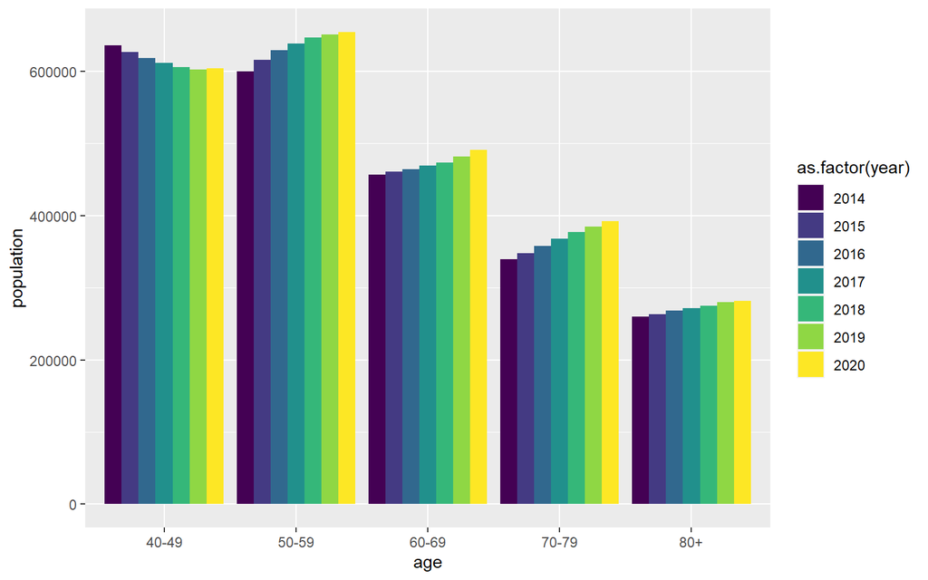

## Predicting 2020 & 2021 pops

For each age, sex, nationality stratum, for each municipality separately, Poisson model was fitted using the 2014-2019 data; then prediction was made for 2020 & 2021 years. The gist of this operation was to exclude the effect of pandemic from the population counts in years affected.

```r
population_ext_poi <- population %>%
  filter(year != 2020) %>%
  # filter(GMDNR == 261 | GMDNR == 389) %>%
  group_by(GMDNR, age, sex) %>%
  do(glm(population ~ year, data = ., family = "poisson") %>%
       predict(., newdata = tibble(year = c(as.integer(2020), as.integer(2021))), type = "response") %>%
       tibble(
         year = c(as.integer(2020), as.integer(2021)),
         population_ext_poi = .
       )) %>%
  ungroup() %>%
  mutate(population_ext_poi = as.integer(round(population_ext_poi))) %>%
  arrange(year, GMDNR, sex, age) %>%
  relocate(year)
```

Summary of values:

```
    Min.  1st Qu.   Median     Mean  3rd Qu.     Max.     NA's
     0.0     42.0    108.0    337.5    283.0 119587.0        4
```

**Note:** *4 NAs!*

```
# A tibble: 7 × 6
   year GMDNR GMDNAME sex   age   population
  <int> <dbl> <chr>   <chr> <chr>      <int>
1  2014  4232 Geltwil Male  80+            0
2  2015  4232 Geltwil Male  80+            0
3  2016  4232 Geltwil Male  80+            0
4  2017  4232 Geltwil Male  80+            0
5  2018  4232 Geltwil Male  80+            0
6  2019  4232 Geltwil Male  80+            1
7  2020  4232 Geltwil Male  80+            3
```

```
# A tibble: 2 × 5
   year GMDNR age   sex   population_ext_poi
  <int> <dbl> <chr> <chr>              <int>
1  2020  4232 80+   Male                  NA
2  2021  4232 80+   Male                  NA
```

```
# A tibble: 7 × 6
   year GMDNR GMDNAME   sex   age   population
  <int> <dbl> <chr>     <chr> <chr>      <int>
1  2014   389 Meienried Male  80+            0
2  2015   389 Meienried Male  80+            0
3  2016   389 Meienried Male  80+            0
4  2017   389 Meienried Male  80+            0
5  2018   389 Meienried Male  80+            0
6  2019   389 Meienried Male  80+            1
7  2020   389 Meienried Male  80+            1
```

```
# A tibble: 2 × 5
   year GMDNR age   sex   population_ext_poi
  <int> <dbl> <chr> <chr>              <int>
1  2020   389 80+   Male                  NA
2  2021   389 80+   Male                  NA
```

### Results in large municipality

Results for large municipality are fine.

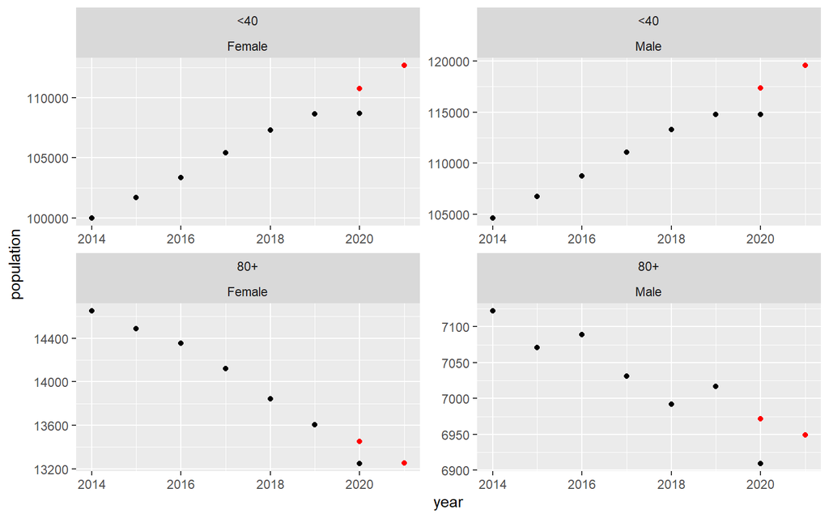

### Results in small municipality

For small municipality we might end up with sth more wiggly.

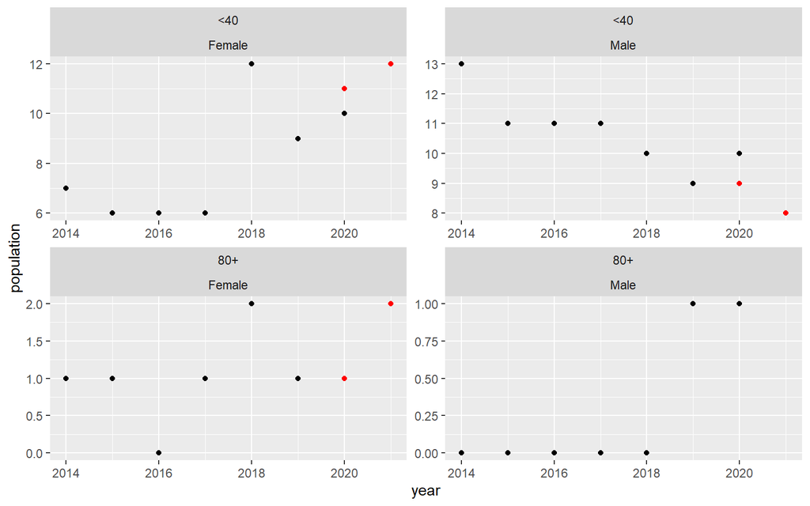

**Note lack of prediction for 2020 & 2021 for oldest males!**

There are two municipalities with missing predictions for oldest males:

```
# A tibble: 2 × 4
  GMDNR age   sex   GMDNAME
  <dbl> <chr> <chr> <chr>
1   389 80+   Male  Meienried
2  4232 80+   Male  Geltwil
```

Population in this strata was replaced by estimates of a simple linear model.

```r
population_ext_lm <- population %>%
  filter(year != 2020) %>%
  # filter(GMDNR == 261 | GMDNR == 389) %>%
  group_by(GMDNR, age, sex) %>%
  do(lm(population ~ year, data = .) %>%
       predict(., newdata = tibble(year = c(as.integer(2020), as.integer(2021)))) %>%
       tibble(
         year = c(as.integer(2020), as.integer(2021)),
         population_ext_lm = .
       )) %>%
  ungroup() %>%
  mutate(population_ext_lm = as.integer(round(population_ext_lm))) %>%
  arrange(year, GMDNR, sex, age) %>%
  relocate(year)
```

## Getting mid-year pops

For each age, sex, nationality stratum, for each municipality separately, simple mean of the two years of data is used to estimate the middle point. In such case we use, for instance data from 31st Dec 2014 and 31st Dec 2015 to estimate population mid-2015.

```r
data <- population %>%
  filter(year < 2020) %>%
  bind_rows(population_ext_poi) %>%
  # 2020 replaced by estimates from poisson
  mutate(population = if_else(year >= 2020,
                              population_ext_poi, population
  )) %>%
  # replacing two missing strata with lm estimates
  left_join(population_ext_lm) %>%
  mutate(population = if_else(year >= 2020 & is.na(population_ext_poi),
                              population_ext_lm, population
  )) %>%
  select(-population_ext_poi, -population_ext_lm)

for (i in 2014:2020) {
  result <- data %>%
    filter(year >= i & year <= i + 1) %>%
    # filter(GMDNR == 261 | GMDNR == 389) %>%
    group_by(GMDNR, age, sex) %>%
    summarise(population_mid_poi = mean(population)) %>%
    ungroup() %>%
    mutate(
      year = as.integer(i + 1),
      population_mid_poi = as.integer(round(population_mid_poi))
    ) %>%
    arrange(year, GMDNR, sex, age)

  if (i == 2014) {
    population_mid_poi <- result
  } else {
    population_mid_poi <- bind_rows(population_mid_poi, result)
  }
}
```

### Large municipality

Again, results for large municipality are fine:

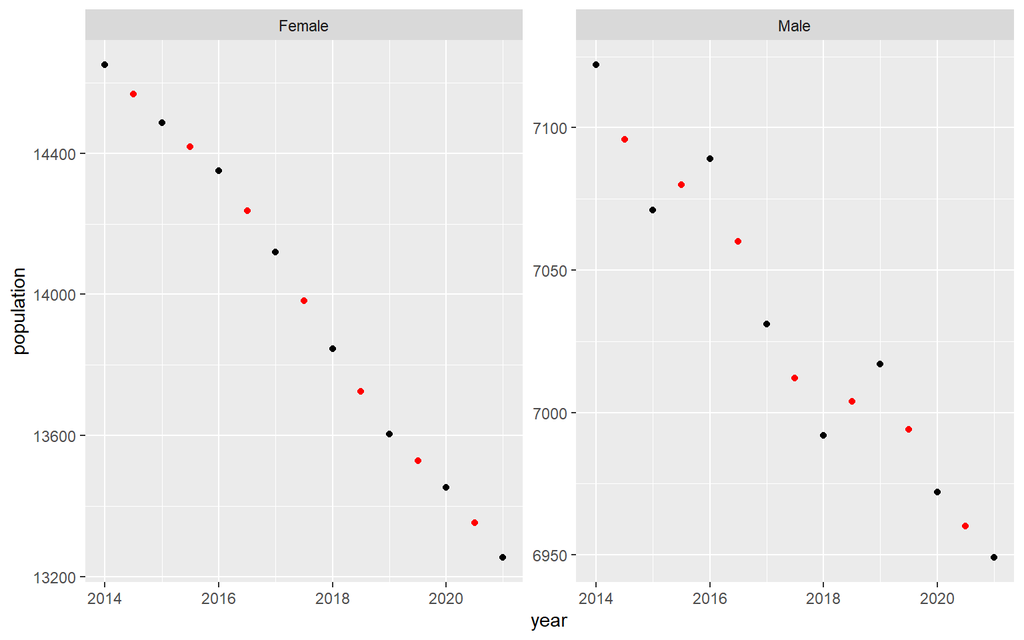

### Small municipality

Again, for small municipality we might end up with sth more wiggly.

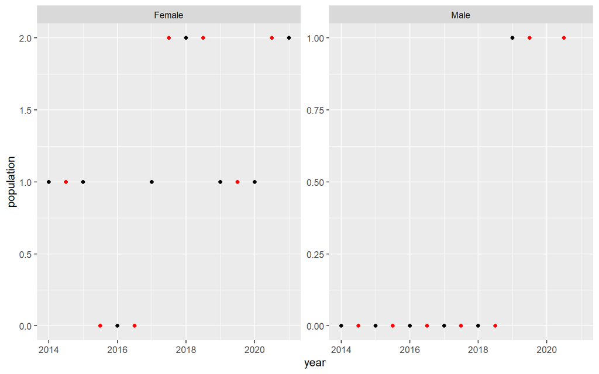

## Deaths <-> population link

Prepared population file is merged to deaths dataset prepared in `02.Rmd`.

**We use file based on place of residence.**

Non-existent population count `communityXyearXageXsexXnationality` strata are assumed to mean 0 pops.

```r
w_deaths_2015_2021_pop <- read_rds("data/BfS-closed/monthly_deaths/w_deaths_2015_2021_exp.Rds") %>%
  left_join(population) %>%
  mutate(population = ifelse(year < 2021 & is.na(population), 0, population)) %>%
  left_join(population_mid_poi) %>%
  mutate(population_mid_poi = ifelse(is.na(population_mid_poi), 0, population_mid_poi))
```

## Deaths > population problem

```r
surplus <- w_deaths_2015_2021_pop %>%
  filter(deaths > population) %>%
  arrange(GMDNR, date) %>%
  mutate(difference = population - deaths)
```

There are 23 strata from 20 communities where count of deaths is larger than count of population. The difference is in range of 1-2 and refers to very small counts of deaths/pops.

|  | GMDNAME | KTNAME | year | month | age | sex | deaths | population | population_mid_poi | difference |
| --- | --- | --- | --- | --- | --- | --- | --- | --- | --- | --- |
| 1 | Meienried | BE | 2016 | 8 | 80+ | Female | 1 | 0 | 0 | -1 |
| 2 | Rumendingen | BE | 2016 | 4 | 80+ | Male | 1 | 0 | 0 | -1 |
| 3 | Deisswil bei Münchenbuchsee | BE | 2020 | 1 | 80+ | Female | 1 | 0 | 2 | -1 |
| 4 | Deisswil bei Münchenbuchsee | BE | 2020 | 7 | 80+ | Female | 1 | 0 | 2 | -1 |
| 5 | Berken | BE | 2016 | 5 | 80+ | Male | 1 | 0 | 0 | -1 |
| 6 | Prévondavaux | FR | 2015 | 11 | 80+ | Female | 1 | 0 | 0 | -1 |
| 7 | Balm bei Günsberg | SO | 2016 | 8 | 80+ | Female | 1 | 0 | 0 | -1 |
| 8 | Rongellen | GR | 2018 | 3 | 70-79 | Male | 1 | 0 | 0 | -1 |
| 9 | Rongellen | GR | 2018 | 12 | 80+ | Male | 1 | 0 | 0 | -1 |
| 10 | Campo (Vallemaggia) | TI | 2020 | 1 | 80+ | Female | 1 | 0 | 2 | -1 |

[output cut: 13 more lines]

# STATPOP

```r
statpop2020 <- read_delim("data-raw/BfS-closed/STATPOP/statpop2020_220098p.zip",
                          delim = ";", escape_double = FALSE,
                          col_types = cols(STATYEAR = col_integer(),
                                           SEX = col_integer(),
                                           TYPEOFRESIDENCE = col_integer(),
                                           POPULATIONTYPE = col_integer(),
                                           AGE = col_integer(),
                                           CLASSAGEFIVEYEARS = col_integer(),
                                           NATIONALITYCATEGORY = col_integer(),
                                           MAINRESIDENCECATEGORY = col_integer(),
                                           GEOCOORDE = col_integer(),
                                           GEOCOORDN = col_integer(),
                                           INDIC_EGID = col_integer(),
                                           statdate = col_date(format = "%d/%m/%Y")),
                          trim_ws = TRUE) %>%
  janitor::remove_empty(c("rows", "cols")) %>% janitor::clean_names()

statpop2020_agg <- statpop2020 %>%
  rename(egid = federalbuildingid) %>%
  filter(typeofresidence == 1) %>%
  filter(populationtype == 1) %>%
  filter(mainresidencecategory == 1) %>%
  filter(indic_egid == 1) %>%
  select(-statyear, -statdate,
         -typeofresidence, -populationtype, -mainresidencecategory,
         -indic_egid) %>%
  group_by(egid, geocoorde, geocoordn) %>%
  summarise(pop = n()) %>%
  ungroup() %>%
  st_as_sf(coords = c("geocoorde", "geocoordn"),
           crs = 2056)
```

Using data from `STATPOP` **2020**.

Dataset consists of 8,859,558 individuals and 1,549,502 buildings. We selected individuals with type of residence *Hauptwohnsitz*, population type *Ständige Wohnbevölkerung*, main residency category *Nur ein Hauptwohnsitz* and with valid EGID building ID.

# Voting

Data from `swissdd` [package](https://github.com/politanch/swissdd).

Linked to municipality boundaries from `2022-01-01`.

```r
st_gg22 <- read_rds("data/swisstopo/st_gg22.Rds")
```

## June vote

> Bundesgesetz vom 25.09.2020 über die gesetzlichen Grundlagen für Verordnungen des Bundesrates zur Bewältigung der Covid-19-Epidemie (Covid-19-Gesetz)

### Data

```r
covid_jun <- get_nationalvotes(
  votedates = "2021-06-13",
  geolevel = "municipality"
) %>%
  filter(name == "Bundesgesetz über die gesetzlichen Grundlagen für Verordnungen des Bundesrates zur Bewältigung der Covid-19-Epidemie (Covid-19-Gesetz)") %>%
  select(-name, -id)
```

Dataset consists of 2,141 communities.

### Results preview

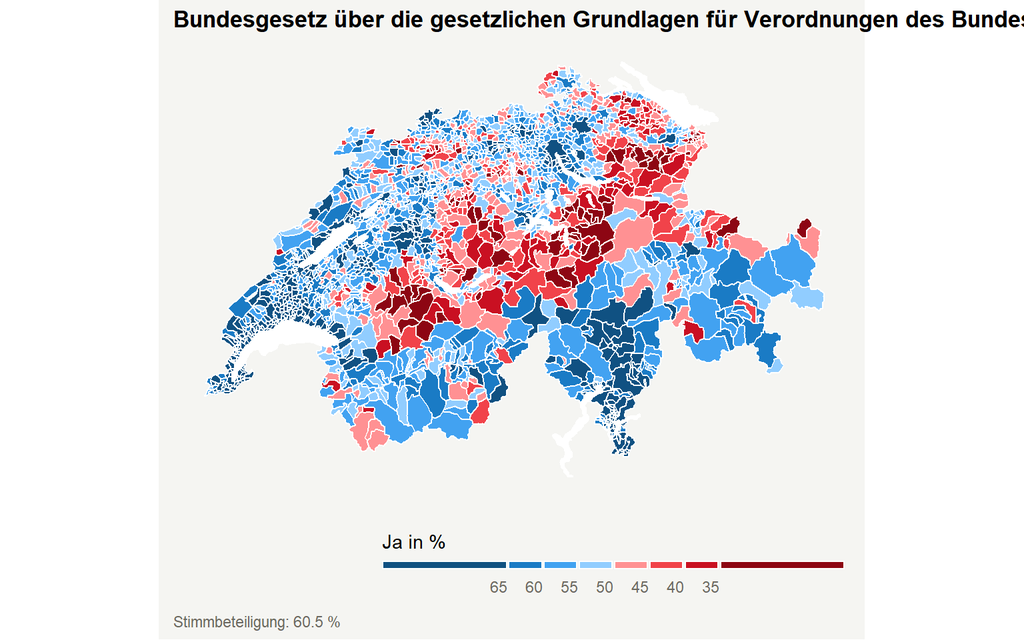

### Link to municipalities

Using `GMDNR` / `mun_id` for deterministic linkage.

```r
covid_jun_gem <- st_gg22 %>%
  left_join(covid_jun)
```

There are few communities that exist on the map but do not exist in the voting dataset:

```
# A tibble: 9 × 2
  GMDNR GMDNAME
  <dbl> <chr>
1   389 Meienried
2   408 Hellsau
3   535 Deisswil bei Münchenbuchsee
4   877 Niedermuhlern
5  3103 Rüte
6  3105 Schwende
7  5195 Maroggia
8  5197 Melano
9  5219 Rovio
```

## November vote

> Änderung des Bundesgesetzes über die gesetzlichen Grundlagen für Verordnungen des Bundesrates zur Bewältigung der Covid-19-Epidemie (Covid-19-Gesetz) (Härtefälle, Arbeitslosenversicherung, familienergänzende Kinderbetreuung, Kulturschaffende, Veranstaltungen)

### Data

```r
covid_nov <- get_nationalvotes(
  votedates = "2021-11-28",
  geolevel = "municipality"
) %>%
  filter(name == "Änderung des Bundesgesetzes über die gesetzlichen Grundlagen für Verordnungen des Bundesrates zur Bewältigung der Covid-19-Epidemie (Covid-19-Gesetz) (Härtefälle, Arbeitslosenversicherung, familienergänzende Kinderbetreuung, Kulturschaffende, Veranstaltungen)") %>%
  select(-name, -id)
```

Dataset consists of 2,141 communities.

### Results preview

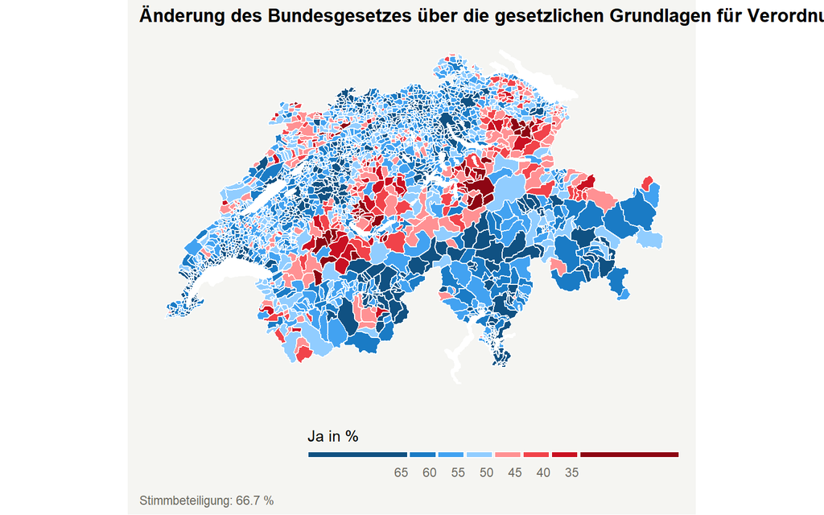

### Link to municipalities

Using `GMDNR` / `mun_id` for deterministic linkage.

```r
covid_nov_gem <- st_gg22 %>%
  left_join(covid_nov)
```

There are again few communities that exist on the map but do not exist in the voting dataset:

```
# A tibble: 9 × 2
  GMDNR GMDNAME
  <dbl> <chr>
1   389 Meienried
2   408 Hellsau
3   535 Deisswil bei Münchenbuchsee
4   877 Niedermuhlern
5  3103 Rüte
6  3105 Schwende
7  5195 Maroggia
8  5197 Melano
9  5219 Rovio
```